# Árboles de predicción: bagging, random forest, boosting y C5.0

### Definir el peso de errores

En muchos escenarios, las consecuencias de cometer un error de clasificación son distintas dependiendo el tipo que sean. Por ejemplo, en el ámbito biomédico, no es igual de grave confundir un tumor maligno con uno benigno que viceversa, ya que, en el primer caso, la vida del paciente puede estar en peligro. En el problema de los préstamos de este ejercicio, concederle un préstamo a alguien que no lo va a devolver, es mucho más costoso para el banco que no concedérselo a varios clientes que sí lo devolverían. El algoritmo `C5.0` permite asignar diferentes penalizaciones a cada tipo de error, lo que fuerza al modelo (árbol) a minimizar determinados tipos de error.

El peso o penalización de cada error se pasa en forma de matriz al argumento `costs`. En la matriz se especifica cuánto de costoso es cada error respecto a los demás. En este problema, dado que la variable respuesta es binaria, se necesita una matriz 2x2.

```r
dimensiones <- list(predicho = c("no", "yes"), real = c("no", "yes"))
dimensiones
```

```
## $predicho
## [1] "no"  "yes"
##
## $real
## [1] "no"  "yes"
```

A continuación, se asigna la penalización de cada tipo de error. Se considera que un préstamo no recuperado es 4 veces más costoso para el banco que un cliente perdido. Las predicciones correctas tienen no tienen coste.

```r
coste_errores <- matrix(data = c(0, 1, 4, 0), nrow = 2, dimnames = dimensiones)
coste_errores
```

```
##         real
## predicho no yes
##      no   0   4
##      yes  1   0
```

Por último, se reajusta un modelo, esta vez empleando los pesos y se comparan los resultados frente al modelo que emplea el mismo peso para todos los errores.

```r
# Mismo peso para todos los errores
arbol_clasificacion <- C5.0(default ~ ., data = train)
predicciones <- predict(arbol_clasificacion, newdata = test, type = "class")
table(predicho = predicciones, real = test$default)
```

```
##         real
## predicho no yes
##      no  59  19
##      yes  8  14
```

```r
error_clas <- mean(predicciones != test$default)
paste("El error de clasificación es del:", 100 * error_clas,"%")
```

```
## [1] "El error de clasificación es del: 27 %"
```

```r
# Distinto peso para cada tipo de error
arbol_clasificacion_2 <- C5.0(default ~ ., data = train, costs = coste_errores)
predicciones <- predict(arbol_clasificacion_2, newdata = test, type = "class")
table(predicho = predicciones, real = test$default)
```

```
##         real
## predicho no yes
##      no  37   7
##      yes 30  26
```

```r
error_clas <- mean(predicciones != test$default)
paste("El error de clasificación es del:", 100 * error_clas,"%")
```

```
## [1] "El error de clasificación es del: 37 %"
```

Como consecuencia de las penalizaciones, el error total del modelo aumenta, pero el tipo de error más costoso, se reduce considerablemente. El número de clientes clasificados como “no fraude” pero que realmente sí defraudan se ha reducido de 19 a 7.

### Winnowing

*Winnowing* es una estrategia incorporada en `C5.0` que permite hacer selección de predictores relevantes. Consiste en emplear un algoritmo inicial que identifique los predictores que están relacionados con la variable respuesta para, posteriormente, ajustar el modelo final únicamente con estos predictores. El algoritmo seguido es el siguiente:

1. Se divide aleatoriamente el set de entrenamiento en dos mitades. Con una de ellas se ajusta un árbol (llamado *winnowing tree*) cuya finalidad es evaluar la utilidad de los predictores.
2. Los predictores que no se han utilizado en ninguna división del *winnowing tree* se identifican como no útiles.
3. La otra mitad de las observaciones de entrenamiento, no utilizadas en el ajuste del *winnowing tree*, se emplean para estimar el error del árbol. Se inicia un proceso iterativo en el que se eliminan (de uno en uno) cada uno de los predictores que forman el *winnowing tree*. Si, como resultado de la eliminación, el error del árbol disminuye, se considera que el predictor solo aporta ruido y se identifica como no útil.
4. Una vez que todos los predictores han sido identificados como útiles o no útiles, se reajusta el *winnowing tree* utilizando únicamente los predictores útiles. Si al hacerlo, el error del árbol (calculado con la otra mitad del set de entrenamiento) no se reduce, el proceso de *winnowing* se descarta y no se excluye ningún predictor. Si por lo contrario, el error sí se reduce, se lanza el ajuste `C5.0` convencional, empleando todas las observaciones de entrenamiento pero solo los predictores identificados como útiles.

### Optimización de hiperparámetros

El paquete `C50` no incorpora métodos de validación cruzada para la identificación de los valores óptimos de los hiperparámetros. Sin embargo, es posible hacerlo recurriendo al paquete `caret`.

```r
library(caret)

# Argumentos que pueden evaluarse con caret
getModelInfo(model = "C5.0")[[2]]$parameters
```

| parameter | class | label |
| --- | --- | --- |
| trials | numeric | # Boosting Iterations |
| model | character | Model Type |
| winnow | logical | Winnow |
| cost | numeric | Cost |

```r
# Estrategia de evaluación de los modelos
ctrl <- trainControl(method = "cv", number = 5)

# Hiperparámetros comparados
grid <- expand.grid(model = "tree",
                    trials = c(1, 5, 10, 20, 30, 40, 50, 80, 100),
                    winnow = c(FALSE, TRUE))

set.seed(123)
modelos <- train(default ~ ., data = train,
                 method = "C5.0",
                 trControl = ctrl,
                 tuneGrid = grid)
modelos$bestTune
```

|  | trials | model | winnow |
| --- | --- | --- | --- |
| 14 | 30 | tree | TRUE |

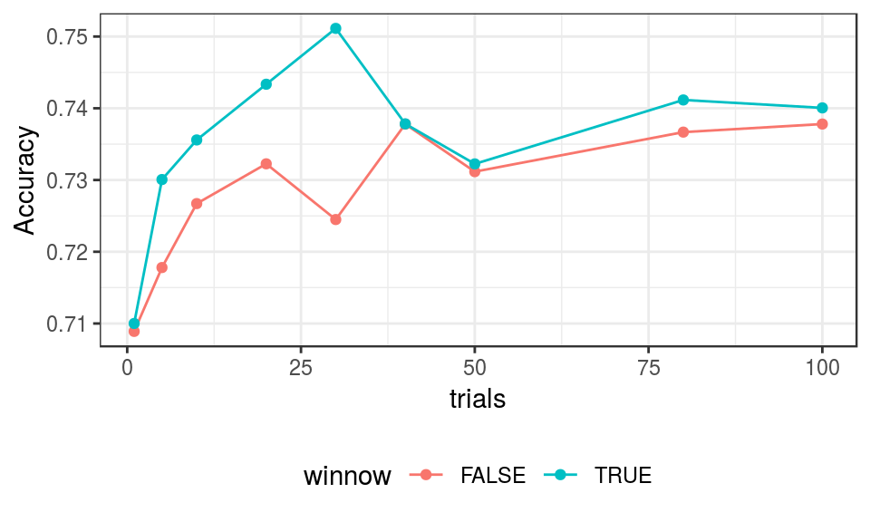

```r
ggplot(data = modelos$results, aes(x = trials, y = Accuracy, color = winnow)) +
  geom_line() +
  geom_point() +
  theme_bw() +
  theme(legend.position = "bottom")
```

# Apuntes varios (miscellaneous)

En este apartado recojo comentarios, definiciones y puntualizaciones que he ido encontrando en diferentes fuentes y que, o bien no he tenido tiempo de introducir en el cuerpo principal del documento, o que he considerado mejor mantenerlos al margen como información complementaria.

## Creación paso a paso de un árbol CART

*Master in Big Data. University of Santiago de Compostela, Manuel Mucientes*

Dado el siguiente conjunto de datos con 6 observaciones, 3 variables de entrada continuas y una variable de salida cualitativa:

```r
library(tidyverse)
x1 <- c(4,-3,3,1,-2,-3)
x2 <- c(3,-1,-2,4,3,5)
x3 <- c(-1,-1,0,0,1,5)
y  <- c(1,0,0,1,0,0)
datos <- data.frame(x1,x2,x3,y)
datos
```

| x1 | x2 | x3 | y |
| --- | --- | --- | --- |
| 4 | 3 | -1 | 1 |
| -3 | -1 | -1 | 0 |
| 3 | -2 | 0 | 0 |
| 1 | 4 | 0 | 1 |
| -2 | 3 | 1 | 0 |
| -3 | 5 | 5 | 0 |

Se construye un árbol de clasificación (sin podar) mediante CART, utilizando como criterio de división la entropía. La condición de parada debe ser que los nodos hoja sean puros (todos los ejemplos son de la misma clase). En cada nodo del árbol se debe indicar:

- La variable y su valor umbral.
- La entropía correspondiente.
- La los nodos hoja, la clase del nodo y los ejemplos que pertenecen al mismo.

Tal como se ha visto en las descripciones teóricas, se trata de un proceso iterativo. Para cada nodo, se evalúan las condiciones de parada, si no se cumplen, se procede con los siguientes pasos:

- Para cada uno de los predictores continuos (en este caso todos):
  - Se ordenan de menor a mayor los valores observados del predictor.
  - Se identifican aquellos puntos en los que se produce un cambio de clase en la variable respuesta.
  - Se identifican como posibles puntos de cortes los valores medios entre cada par de observaciones consecutivas en las que hay cambio de clase.
  - Se calcula el valor de entropía cruzada para cada uno de los puntos de corte identificados en el paso anterior.
- Se selecciona el punto de corte con menor entropía y se divide el nodo acorde a este.
- Se repite el proceso con cada uno de los nuevos nodos.

**Predictor X1**

```r
datos %>% select(x1,y) %>% arrange(x1)
```

| x1 | y |
| --- | --- |
| -3 | 0 |
| -3 | 0 |
| -2 | 0 |
| 1 | 1 |
| 3 | 0 |
| 4 | 1 |

Los posibles puntos de corte para este predictor son: *(-2 + 1)/2 = -0.5, (1 + 3)/2 = 2* y *(4 + 3)/2 = 3.5*

$$D_{(x_1,-0.5)} = \frac{3}{6}(-\frac{3}{3}\log\frac{3}{3} -\frac{0}{3}\log\frac{0}{3}) + \frac{3}{6}(-\frac{1}{3}\log\frac{1}{3} -\frac{2}{3}\log\frac{2}{3})$$

En el cálculo de la entropía, cuando una división tiene como resultado un nodo puro aparece en la ecuación la operación $0 \cdot log(0)$, lo que equivale a $0 \cdot - \infty$, cuyo resultado es indeterminación. Dado que se trata de un nodo puro, su entropía es nula y por lo tanto, se considera que el término estero es 0. Para que la operación no genere un *NaN* al implementarla en R, se calculan primero los términos de cada partición por separado, se sustituyen por cero las indeterminaciones y luego se suman.

```r
d = c((3/6)*(-(3/3) * log(3/3) -(0/3) * log(0/3)), (3/6)*(-(1/3) * log(1/3) - (2/3) * log(2/3)))
d[is.nan(d)] <- 0
sum(d)
```

```
## [1] 0.3182571
```

$$D_{(x_1,2)} = \frac{4}{6}(-\frac{3}{4}\log\frac{3}{4} -\frac{1}{4}\log\frac{1}{4}) + \frac{2}{6}(-\frac{1}{2}\log\frac{1}{2} -\frac{1}{2}\log\frac{1}{2})$$

```r
d = c((4/6)*(-(3/4) * log(3/4) -(1/4) * log(1/4)), (2/6)*(-(1/2) * log(1/2) - (1/2) * log(1/2)))
d[is.nan(d)] <- 0
sum(d)
```

```
## [1] 0.6059392
```

$$D_{(x_1,3.5)} = \frac{5}{6}(-\frac{4}{5}\log\frac{4}{5} -\frac{1}{5}\log\frac{1}{5}) + \frac{1}{6}(-\frac{0}{1}\log\frac{0}{1} -\frac{1}{1}\log\frac{1}{1})$$

```r
d = c((5/6)*(-(4/5) * log(4/5) -(1/5) * log(1/5)), (12/6)*(-(0/1) * log(0/1) - (1/1) * log(1/1)))
d[is.nan(d)] <- 0
sum(d)
```

```
## [1] 0.417002
```

**Predictor X2**

```r
datos %>% select(x2, y) %>% arrange(x2)
```

| x2 | y |
| --- | --- |
| -2 | 0 |
| -1 | 0 |
| 3 | 1 |
| 3 | 0 |
| 4 | 1 |
| 5 | 0 |

Cuando para un mismo valor del predictor existen dos o más observaciones con clases distintas, se establece un posible punto de corte a cada lado de la misma. En este caso, para $X_2 = 3$ existe una observación de clase *0* y otra de clase *1*. Los posibles puntos de corte para este predictor son: *(-1 + 3)/2 = 1, (3 + 4)/2 = 3.5* y *(4 + 5)/2 = 4.5.*

$$D_{(x_2, 1)} = \frac{2}{6}(-\frac{2}{2}\log\frac{2}{2} -\frac{0}{2}\log\frac{0}{2}) + \frac{4}{6}(-\frac{2}{4}\log\frac{2}{4} -\frac{2}{4}\log\frac{2}{4})$$

```r
d = c((2/6)*(-(2/2) * log(2/2) -(0/2) * log(0/2)), (4/6)*(-(2/4) * log(2/4) - (2/4) * log(2/4)))
d[is.nan(d)] <- 0
sum(d)
```

```
## [1] 0.4620981
```

$$D_{(x_2, 3.5)} = \frac{4}{6}(-\frac{3}{4}\log\frac{3}{4} -\frac{1}{4}\log\frac{1}{4}) + \frac{2}{6}(-\frac{1}{2}\log\frac{1}{2} -\frac{1}{2}\log\frac{1}{2})$$

```r
d = c((4/6)*(-(3/4) * log(3/4) -(1/4) * log(1/4)), (2/6)*(-(1/2) * log(1/2) - (1/2) * log(1/2)))
d[is.nan(d)] <- 0
sum(d)
```

```
## [1] 0.6059392
```

$$D_{(x_2, 4.5)} = \frac{5}{6}(-\frac{3}{5}\log\frac{3}{5} -\frac{2}{5}\log\frac{2}{5}) + \frac{1}{6}(-\frac{1}{1}\log\frac{1}{1} -\frac{0}{1}\log\frac{0}{1})$$

```r
d = c((5/6)*(-(3/5) * log(3/5) -(2/5) * log(2/5)), (1/6)*(-(1/1) * log(1/1) - (0/1) * log(0/1)))
d[is.nan(d)] <- 0
sum(d)
```

```
## [1] 0.5608431
```

**Predictor X3**

```r
datos %>% select(x3, y) %>% arrange(x3)
```

| x3 | y |
| --- | --- |
| -1 | 1 |
| -1 | 0 |
| 0 | 0 |
| 0 | 1 |
| 1 | 0 |
| 5 | 0 |

Los posibles puntos de corte para este predictor son: *(-1 + 0)/2 = -0.5* y *(0 + 1)/2 = 0.5*.

$$D_{(x_3, -0.5)} = \frac{2}{6}(-\frac{1}{2}\log\frac{1}{2} -\frac{1}{2}\log\frac{1}{2}) + \frac{4}{6}(-\frac{3}{4}\log\frac{3}{4} -\frac{1}{4}\log\frac{1}{4})$$

```r
d = c((2/6)*(-(1/2) * log(1/2) -(1/2) * log(1/2)), (4/6)*(-(3/4) * log(3/4) - (1/4) * log(1/4)))
d[is.nan(d)] <- 0
sum(d)
```

```
## [1] 0.6059392
```

$$D_{(x_3, 0.5)} = \frac{4}{6}(-\frac{2}{4}\log\frac{2}{4} -\frac{2}{4}\log\frac{2}{4}) + \frac{2}{6}(-\frac{2}{2}\log\frac{2}{2} -\frac{0}{2}\log\frac{0}{2})$$

```r
d = c((4/6)*(-(2/4) * log(2/4) -(2/4) * log(2/4)), (2/6)*(-(2/2) * log(2/2) - (0/2) * log(0/2)))
d[is.nan(d)] <- 0
sum(d)
```

```
## [1] 0.4620981
```

De todos los posibles puntos de corte, el que consigue la menor entropía total es *X_1 = -0.5*.

```r
predictor <- c("x1", "x1", "x1", "x2", "x2", "x2", "x3", "x3")
valor_division <- c(-0.5, 2, 3.5, 1, 3.5, 4.5, -0.5, 0.5)
entropia  <- c(0.318, 0.606, 0.417, 0.462, 0.606, 0.56, 0.606, 0.462)
data.frame(predictor, valor_division, entropia) %>% arrange(entropia)
```

| predictor | valor_division | entropia |
| --- | --- | --- |
| x1 | -0.5 | 0.318 |
| x1 | 3.5 | 0.417 |
| x2 | 1.0 | 0.462 |
| x3 | 0.5 | 0.462 |
| x2 | 4.5 | 0.560 |
| x1 | 2.0 | 0.606 |
| x2 | 3.5 | 0.606 |
| x3 | -0.5 | 0.606 |

Esta división da lugar a dos nuevos nodos:

$X_1 \leq -0.5$

```r
nodo_1 <- datos %>% filter(x1 <= -0.5)
nodo_1
```

| x1 | x2 | x3 | y |
| --- | --- | --- | --- |
| -3 | -1 | -1 | 0 |
| -2 | 3 | 1 | 0 |
| -3 | 5 | 5 | 0 |

$X_1 > -0.5$

```r
nodo_2 <- datos %>% filter(x1 > -0.5)
nodo_2
```

| x1 | x2 | x3 | y |
| --- | --- | --- | --- |
| 4 | 3 | -1 | 1 |
| 3 | -2 | 0 | 0 |
| 1 | 4 | 0 | 1 |

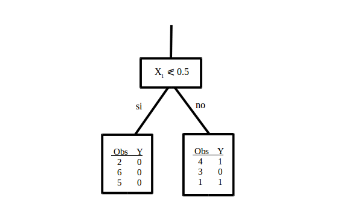

El nodo 1 es puro, todas las observaciones que contiene pertenecen a la clase *0*, por lo que se detiene su división, es un nodo terminal. El nodo 2 no cumple la condición de parada, por lo que se repite el proceso de división.

**Predictor X1**

```r
nodo_2 %>% select(x1,y) %>% arrange(x1)
```

| x1 | y |
| --- | --- |
| 1 | 1 |
| 3 | 0 |
| 4 | 1 |

Los posibles puntos de corte para este predictor son: *(1 + 3)/2 = 2* y *(3 + 4)/2 = 3.5*.

$$D_{(x_1,2)} = \frac{1}{3}(-\frac{0}{1}\log\frac{0}{1} -\frac{1}{1}\log\frac{1}{1}) + \frac{2}{3}(-\frac{1}{2}\log\frac{1}{2} -\frac{1}{2}\log\frac{1}{2})$$

```r
d = c((1/3)*(-(0/1) * log(0/1) -(1/1) * log(1/1)), (2/3)*(-(1/2) * log(1/2) - (1/2) * log(1/2)))
d[is.nan(d)] <- 0
sum(d)
```

```
## [1] 0.4620981
```

$$D_{(x_1,3.5)} = \frac{2}{3}(-\frac{1}{2}\log\frac{1}{2} -\frac{1}{2}\log\frac{1}{2}) + \frac{1}{3}(-\frac{0}{1}\log\frac{0}{1} -\frac{1}{1}\log\frac{1}{1})$$

```r
d = c((2/3)*(-(1/2) * log(1/2) - (1/2) * log(1/2)), (1/3)*(-(0/1) * log(0/1) -(1/1) * log(1/1)))
d[is.nan(d)] <- 0
sum(d)
```

```
## [1] 0.4620981
```

**Predictor X2**

```r
nodo_2 %>% select(x2,y) %>% arrange(x2)
```

| x2 | y |
| --- | --- |
| -2 | 0 |
| 3 | 1 |
| 4 | 1 |

Los posibles puntos de corte para este predictor son: *(-2 + 3)/2 = 0.5*.

$$D_{(x_2,0.5)} = \frac{1}{3}(-\frac{1}{1}\log\frac{1}{1} -\frac{0}{1}\log\frac{0}{1}) + \frac{2}{3}(-\frac{0}{2}\log\frac{0}{2} -\frac{2}{2}\log\frac{2}{2})$$

```r
d = c((1/3)*(-(1/1) * log(1/1) - (0/1) * log(0/1)), (2/3)*(-(0/2) * log(0/2) -(2/2) * log(2/2)))
d[is.nan(d)] <- 0
sum(d)
```

```
## [1] 0
```

**Predictor X3**

```r
nodo_2 %>% select(x3,y) %>% arrange(x3)
```

| x3 | y |
| --- | --- |
| -1 | 1 |
| 0 | 0 |
| 0 | 1 |

Los posibles puntos de corte para este predictor son: *(-1 + 0)/2 = -0.5*.

$$D_{(x_3, -0.5)} = \frac{1}{3}(-\frac{0}{1}\log\frac{0}{1} -\frac{1}{1}\log\frac{1}{1}) + \frac{2}{3}(-\frac{1}{2}\log\frac{1}{2} -\frac{1}{2}\log\frac{1}{2})$$

```r
d = c((1/3)*(-(0/1) * log(0/1) - (1/1) * log(1/1)), (2/3)*(-(1/2) * log(1/2) -(1/2) * log(1/2)))
d[is.nan(d)] <- 0
sum(d)
```

```
## [1] 0.4620981
```

De todos los puntos de corte evaluados para el nodo 2, el que consigue la menor entropía total es *X_2 = 0.5*.

```r
predictor <- c("x1", "x1", "x2", "x3")
valor_division <- c(2, 3.5, 0.5, -0.5)
entropia  <- c(0.462, 0.462, 0, 0.462)
data.frame(predictor, valor_division, entropia) %>% arrange(entropia)
```

| predictor | valor_division | entropia |
| --- | --- | --- |
| x2 | 0.5 | 0.000 |
| x1 | 2.0 | 0.462 |
| x1 | 3.5 | 0.462 |
| x3 | -0.5 | 0.462 |

Esta división da lugar a dos nuevos nodos, ambos puros, por lo que se detiene el crecimiento del árbol. Como resultado del proceso se ha generado un árbol con 3 nodos terminales.

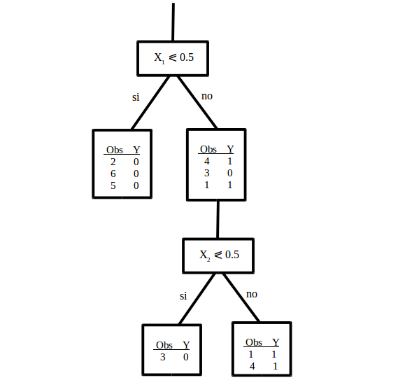

# Bibliografía

*Introduction to Statistical Learning, Gareth James, Daniela Witten, Trevor Hastie and Robert Tibshirani*

*Applied Predictive Modeling Max Kuhn, Kjell Johnson*

*Top 10 algorithms in data mining by Xindong Wu, Vipin Kumar, J. Ross Quinlan, Joydeep Ghosh, Qiang Yang, Hiroshi Motoda, Geoffrey J. McLachlan, Angus Ng, Bing Liu, Philip S. Yu Zhi-Hua Zhou, Michael Steinbach, David J. Hand, Dan Steinberg*

*Machine Learning with R by Brett Lantz*

[*CMU Statistics*](https://www.stat.cmu.edu/~cshalizi/350/lectures/22/lecture-22.pdf)

*Classification and regression trees. Wei-Yin Loh*

[Trevor Hastie - Gradient Boosting Machine Learning - YouTube](https://www.youtube.com/watch?v=wPqtzj5VZus)

[Ensemble Learning to Improve Machine Learning Results](https://blog.statsbot.co/ensemble-learning-d1dcd548e936)

[Generalized Boosted Models: A guide to the gbm package](http://www.saedsayad.com/docs/gbm2.pdf)

https://en.wikipedia.org/wiki/Gradient_boosting

[Classification Using C5.0](https://static1.squarespace.com/static/51156277e4b0b8b2ffe11c00/t/51e7e42ce4b0fd2e32684bca/1374151724529/user_C5.0.pdf)

This work by Joaquín Amat Rodrigo is licensed under a [Creative Commons Attribution 4.0 International License](http://creativecommons.org/licenses/by/4.0/).